# IQR and Boxplots

### Boxplot and Fences

A Tukey-style boxplot like the one produced by `geom_boxplot()` typically uses Tukey’s “hinge” idea of quartiles to define the enda of the box. The lower hinge is the median of the lower half of the ordered data up to and including the median (if the media is a data point). The upper hinge is the median of the upper half of the data. Boxplots may be drawn horizontally or vertically. In either case, the other axis has labels that are not meaningful.

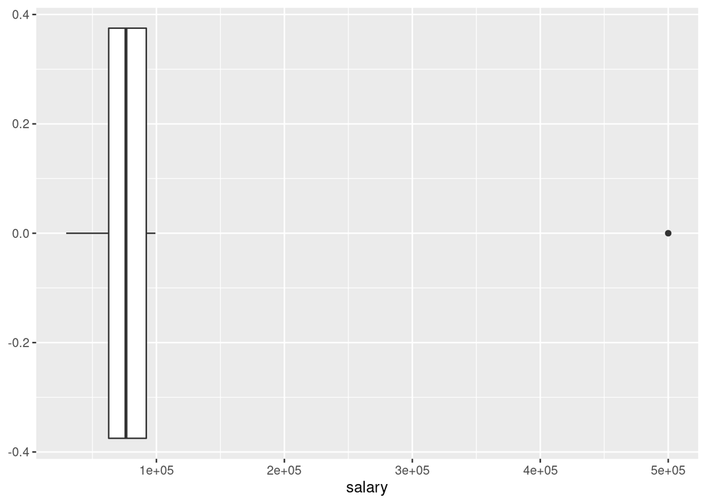

```r
ggplot(data, aes(x = salary)) +
  geom_boxplot()
```

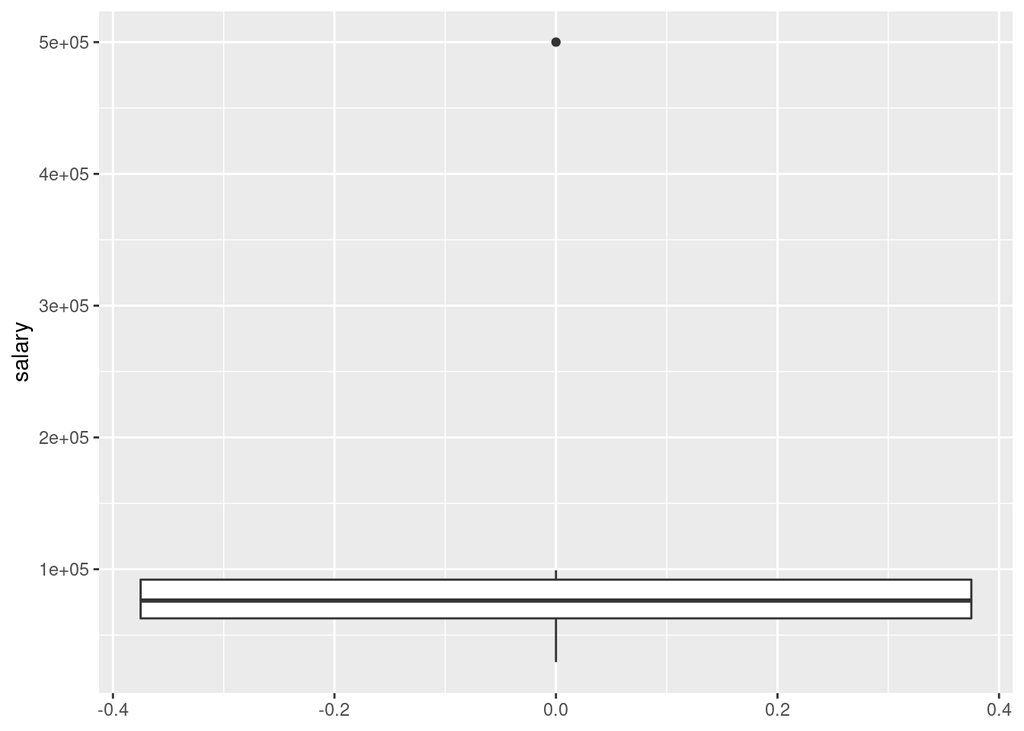

```r
ggplot(data, aes(y = salary)) +
  geom_boxplot()
```

We can format the boxplot for better presentation, including outlier [shape](https://blog.albertkuo.me/post/point-shape-options-in-ggplot/).

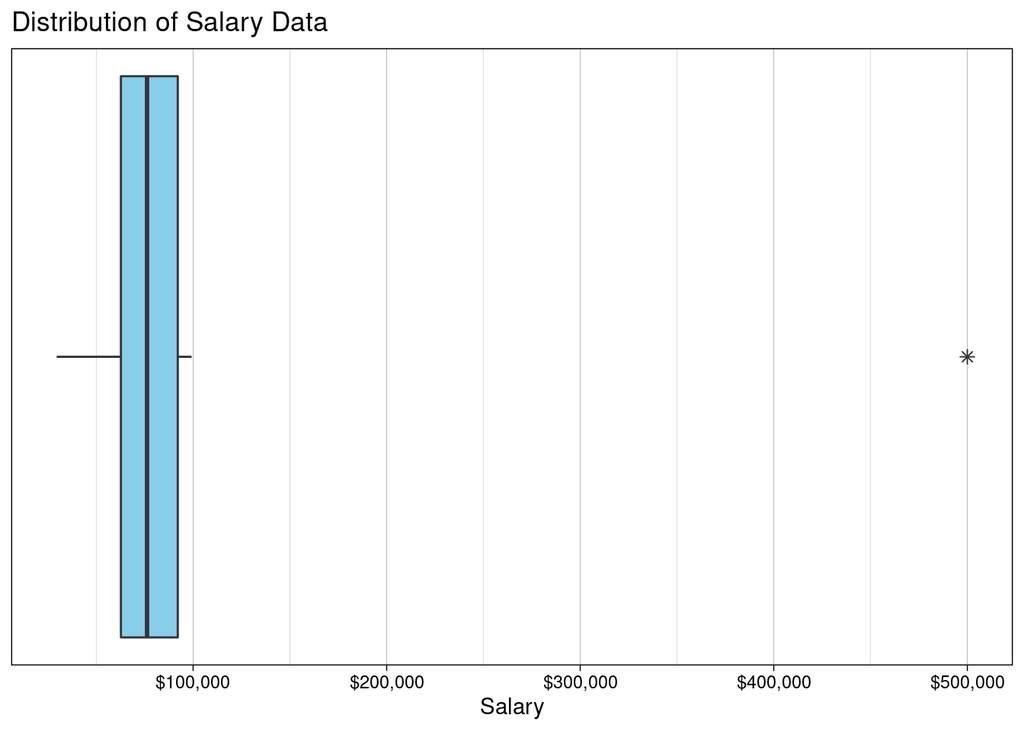

```r
ggplot(data, aes(x = salary)) +
  geom_boxplot(
    fill = "skyblue",
    outlier.shape = 8,
    outlier.size = 2
  ) +
  scale_x_continuous(labels = scales::dollar_format()) +
  scale_y_continuous(breaks = NULL) +
  labs(
    title = "Distribution of Salary Data",
    x = "Salary"
  ) +
  theme_linedraw()
```

The limits for determining outliers are also commonly called “fences”.

```r
fences <- data %>%
  summarize(
    LF = quantile(salary, 0.25) - 1.5 * IQR(salary),
    UF = quantile(salary, 0.75) + 1.5 * IQR(salary)
  )
fences
```

```
# A tibble: 1 × 2
      LF      UF
   <dbl>   <dbl>
1 18638. 136138.
```

We can use the fence values to filter the dataset and find the outliers.

```r
outliers <- data %>%
  filter(salary < fences$LF | salary > fences$UF)
outliers
```

```
# A tibble: 1 × 2
  orderID salary
    <int>  <dbl>
1      12 500000
```

## Guines Pig Survival Example

Boxplots can also be used to compare groups. Consider how they compare to the [histograms](https://stat-jet-asu.github.io/STT3850DataAnalysis1/VideoCode/JBStatsMeasuresOfCentralTendency.html) from an earlier video.

```r
gp %>%
  group_by(group) %>%
  summarize(
    min = min(survivaldays),
    Q1 = quantile(survivaldays, 0.25),
    med = median(survivaldays),
    Q3 = quantile(survivaldays, 0.75),
    max = max(survivaldays),
    iqr = IQR(survivaldays)
  ) %>%
  kable(digits = 1) %>% # 1 decimal place
  kable_styling(
    full_width = FALSE,
    position = "left",
    font_size = 14
  )
```

| group | min | Q1 | med | Q3 | max | iqr |
| --- | --- | --- | --- | --- | --- | --- |
| control | 18 | 149.0 | 341.0 | 576 | 735 | 427.0 |
| treatment | 76 | 158.5 | 214.5 | 296 | 598 | 137.5 |

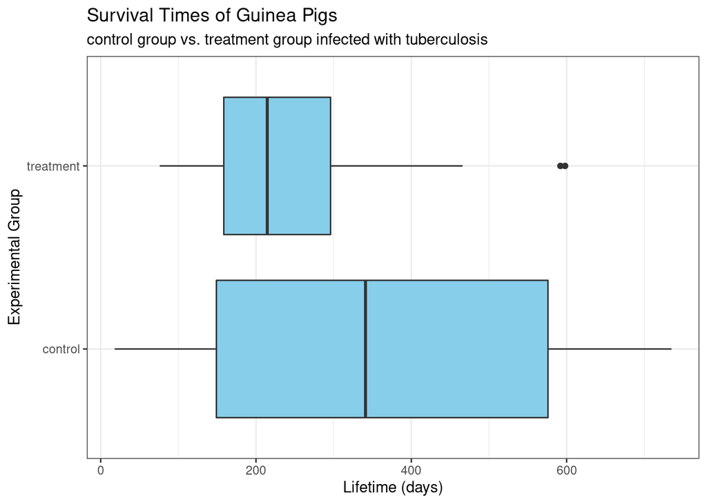

```r
ggplot(gp, aes(x = survivaldays, y = group)) +
  geom_boxplot(fill = "skyblue") +
  labs(
    title = "Survival Times of Guinea Pigs",
    subtitle = "control group vs. treatment group infected with tuberculosis",
    x = "Lifetime (days)",
    y = "Experimental Group"
  ) +
  theme_bw()
```

Each group will have its own fences. The two groups have similar Q1 values, but the much wider IQR of the control group means its upper fence is more than twice as large as the treatment group. The outliers we see in the treatment group are approximately the same number of days as Q3 in the control group. Notice that the lower fences are negative, even though survival days cannot be less than zero. The algebra of the fence calculations does not take the natural limits of the variable into account.

```r
fences <- gp %>%
  group_by(group) %>%
  summarize(
    LF = quantile(survivaldays, 0.25) - 1.5 * IQR(survivaldays),
    UF = quantile(survivaldays, 0.75) + 1.5 * IQR(survivaldays)
  )
fences
```

```
# A tibble: 2 × 3
  group         LF    UF
  <chr>      <dbl> <dbl>
1 control   -492.  1216.
2 treatment  -47.8  502.
```

### References

Tidyverse: [Summarise each group to fewer rows](https://dplyr.tidyverse.org/reference/summarise.html)

Tidyverse: [A Box and Whiskers Plot (in the style of Tukey)](https://ggplot2.tidyverse.org/reference/geom_boxplot.html)